# Лекция 7. Фиксированные эффекты

Блок 2. Панель RLMS

Карен Аванесян

Каузальный анализ в R на данных RLMS-HSE

# Зачем

## Главный козырь панели

блок 1

### «Мы видим все конфаундеры»

Всё стояло на одном допущении: мы **видим** всё, от чего зависит отбор. В RLMS мы не видим способности, мотивацию, семейный капитал, здоровье в детстве.

панель

### «Ненаблюдаемые постоянны во времени»

Другой тип допущения. Цена: эффект оценивается только по тем, у кого воздействие **менялось**, и только по вариации **внутри** человека.

Панель позволяет сравнить человека **с самим собой** в разные годы. Всё, что в человеке **не меняется** — измеренное или нет — выпадает из сравнения автоматически.

## Пример занятия

56 948 наблюдений: работающие мужчины 25–50, 2000–2025

11 078 мужчин в этой панели

10% из них женились или развелись на глазах RLMS

81 254 наблюдений: женщины 20–45 (бинарный исход)

вопрос 1 · линейная FE

### Премия за брак

Растёт ли зарплата **того же** мужчины, когда он женится? `fixest` и `plm`, тест Хаусмана, Мундлак.

вопрос 2 · бинарный исход

### Ребёнок до 3 лет и занятость

Теряет ли **та же** женщина работу, когда у неё маленький ребёнок? LPM, FE-логит, `bife`, `clogit`, предельные эффекты.

## План занятия

Лекция рассчитана на **сдвоенное занятие** (2 пары): часть 1 — линейные FE, часть 2 — бинарные исходы и диагностика.

пара 1

### Линейные FE

1. Модель и within-преобразование; что FE убирает
2. `fixest`: синтаксис, вывод, ошибки, `^`, `[ ]`, `i()`, `csw()`, `fixef()`, `etable()`
3. `plm`: синтаксис, вывод, тесты; совпадение с `fixest`
4. FE или RE: тест Хаусмана, робастная версия, Мундлак

пара 2

### Бинарные исходы и проверки

5. LPM с FE против FE-логита; проблема инцидентных параметров
6. `feglm`, `bife` + поправка, `clogit`; отношения шансов
7. Предельные эффекты: `avg_slopes()` и `get_APEs()`
8. Диагностика: вариация, коллинеарность, синглтоны, автокорреляция

# Идея

## Модель

$$y_{it} = \tau D_{it} + x_{it}'\beta + \alpha_i + \lambda_t + \varepsilon_{it}$$

- $\alpha_i$ — всё постоянное в человеке $i$: способности, характер, семья, место рождения
- $\lambda_t$ — всё общее для всех в году $t$: инфляция, кризис, ковид
- $D_{it}$ может быть связан с $\alpha_i$ сколь угодно сильно — это не мешает

**Within-преобразование**: вычитаем из каждой переменной её среднее по человеку:

$$y_{it} - \bar y_i = \tau (D_{it} - \bar D_i) + (x_{it} - \bar x_i)'\beta + (\varepsilon_{it} - \bar\varepsilon_i)$$

$\alpha_i$ исчез. Регрессия на отклонениях = регрессия с дамми на каждого человека.

## Что FE убирает и что нет

| Источник смещения | Убирает? |
| --- | --- |
| Постоянные ненаблюдаемые (способности, семья) | **да** |
| Общие шоки по годам (с year FE) | **да** |
| Ненаблюдаемые, **меняющиеся** во времени (шок здоровья → увольнение и → зарплата) | нет |
| Обратная причинность внутри человека (зарплата упала → развод) | нет |
| Ошибки измерения в $D$ | нет — **усиливает** |
| Эффекты постоянных признаков (пол, место рождения) | не оцениваются вовсе |

FE отвечает на вопрос «что происходит с зарплатой того же человека, **когда** меняется D». Если D меняется не случайно — скажем, человек женится, когда карьера пошла вверх — смещение остаётся.

## Кто идентифицирует эффект

- Коэффициент при $D$ в FE-модели опирается только на **переключателей** — тех, у кого $D$ менялось в наблюдаемые годы
- Если переключателей 10 % выборки, это они определяют оценку, и к ним надо присматриваться: кто завершает вуз в 30 лет? кто переходит в неформальный сектор?
- Внутри-человеческая вариация часто мала → стандартные ошибки большие, оценка близка к нулю «по дизайну», а не по сути

Перед FE-регрессией: посчитать переключателей и описать их. После: не сравнивать «эффект упал с 0.2 до 0.05» без вопроса, **у кого** он упал.

## FE, RE или Мундлак?

RE

### Случайные эффекты

$\alpha_i$ — случайный шум, **не связанный** с $X$. Эффективнее, позволяет оценивать постоянные признаки

FE

### Фиксированные эффекты

$\alpha_i$ может быть как угодно связан с $X$. Постоянные признаки не оцениваются

Mundlak

### Correlated RE

RE (или МНК) + средние по человеку $\bar x_i$ как регрессоры. Коэффициенты при $x_{it}$ = FE, а постоянные признаки остаются в модели

- **Тест Хаусмана** сравнивает FE и RE: если оценки расходятся сильнее, чем допускает шум, допущение RE отвергается
- Классическая версия требует iid-ошибок — в панели их не бывает. Рабочая версия — **тест Мундлака** с кластерными ошибками
- Для причинных вопросов — FE по умолчанию; RE/Мундлак — когда нужны постоянные признаки или прогноз

## Бинарный исход: почему логит с FE — особый случай

LPM

### Линейная модель вероятности

`feols(y ~ x | id + year)` — всё как для зарплаты. Коэффициент = п. п. Прогнозы могут выйти за [0, 1]

безусловный FE-логит

### Оцениваем $\alpha_i$ дамми

`feglm`, `bife`. При малом $T$ каждый $\hat\alpha_i$ шумный, и этот шум **смещает** $\hat\beta$: проблема инцидентных параметров (Neyman, Scott 1948)

условный логит

### $\alpha_i$ исключается точно

`clogit`. Условие на $\sum_t y_{it}$ убирает $\alpha_i$ из правдоподобия (Chamberlain 1980). Состоятелен при любом $T$

- Люди, у которых $y$ не менялся (всегда работали / никогда), ничего не говорят о $\beta$: в логите с FE они **выбрасываются**
- Для пробита условного трюка нет → аналитическая поправка смещения (Fernández-Val, Weidner 2016; `bife::bias_corr`)
- Альтернатива без FE: RE-логит/пробит (`lme4::glmer(y ~ x + (1 | idind), family = binomial)`) — снова требует, чтобы $\alpha_i$ не зависел от $X$; спасает тот же приём Мундлака

## Технические вопросы, которые решают всё

- **Кластеризация** по человеку: наблюдения одного человека коррелированы; `vcov = ~idind` — минимум
- **Несбалансированная панель**: FE работает, но истощение не случайно → спросить, кто выпадает (лекция 0)
- **Двусторонние FE** (`| idind + year`) — стандарт; с разновременными воздействиями у них есть проблемы (лекция 10)
- **Лаги исхода** + FE = смещение Никелла при коротких панелях; либо не включать, либо Arellano–Bond
- **Первые разности** — альтернатива FE; совпадают при $T = 2$, иначе разные веса по времени

# Код

## Премия за брак: срез против панели

Женатые мужчины зарабатывают больше. Брак делает продуктивнее — или женятся те, кто и так успешен?

```r
m_pool <- feols(log_wage ~ married + age + age2 + i(educ_level) + urban | year,
                data = men, vcov = ~idind)
m_fe   <- feols(log_wage ~ married + age + age2 | idind + year, data = men, vcov = ~idind)
etable(m_pool, m_fe, keep = "married", depvar = FALSE, fitstat = ~ n,
       headers = c("срез с контролями", "FE"))
```

|  | m_pool | m_fe |
| --- | --- | --- |
|  | срез с контролями | FE |
| married | 0.195*** (0.014) | 0.047** (0.015) |
| _______________ | ________________ | _______________ |
| S.E.: Clustered | by: idind | by: idind |
| Observations | 56,858 | 54,158 |

0.19 → 0.05. Большая часть «премии» — постоянные различия между теми, кто женится, и теми, кто нет. Остаток — то, что меняется в зарплате **того же** мужчины после брака (или перед ним — об этом event study, лекция 8).

## Анатомия `feols()`

```r
m_fe <- feols(
  log_wage ~ married + age + age2   # исход ~ регрессоры (должны меняться внутри человека)
  | idind + year,                   # после «|» — фиксированные эффекты: человек и год
  data     = men,
  vcov     = ~idind,                # ошибки, кластеризованные по человеку (синоним: cluster = ~idind)
  panel.id = ~idind + year          # «кто» и «когда»: нужен для l(), f(), d() и vcov = "NW"/"DK"
)
```

1 · до «|»

Обычная формула. Постоянные признаки (`female`, `birth_year`) писать бессмысленно — их съест `idind`

2 · после «|»

FE не оцениваются как дамми, а «вычитаются» (демининг) — поэтому 8 000 человек считаются за доли секунды

3 · vcov

`"iid"`, `"hetero"`, `~idind`, `~psu`, `"twoway"` (по двум первым FE). **По умолчанию — iid** (с `fixest` 0.13)

4 · panel.id

В курсе задан глобально в `load_panel.R`: `setFixest_estimation(panel.id = ~idind + year)`

## Как читать вывод `summary(feols)`

- Вывод R
- С пояснениями

```
OLS estimation, Dep. Var.: log_wage
Observations: 54,158
Fixed-effects: idind: 8,288,  year: 26
Standard-errors: Clustered (idind)
         Estimate Std. Error t value       Pr(>|t|)
married  0.047122   0.014814    3.18 0.001473541965 **
age      0.044449   0.008262    5.38 0.000000076555 ***
age2    -0.000618   0.000074   -8.32      < 2.2e-16 ***
---
Signif. codes:  0 '***' 0.001 '**' 0.01 '*' 0.05 '.' 0.1 ' ' 1
RMSE: 0.373976     Adj. R2: 0.687487
                 Within R2: 0.004066
```

1 · шапка

**Observations** — после удаления пропусков и синглтонов (56 948 → 54 158). **Fixed-effects** — сколько людей и лет реально в модели

2 · Standard-errors

Тип ошибок. Должно быть **Clustered (idind)**; надпись IID в панели — сигнал, что `vcov` забыли

3 · коэффициенты

`married` = 0.047: в год брака лог-зарплата **того же** мужчины выше на столько (≈ 4.7%) при тех же годовых шоках

4 · RMSE, Adj. R2

R² **с** вкладом FE (0.69): высок, потому что люди сильно различаются уровнем. Ничего не говорит о качестве идентификации

5 · Within R2

Доля **внутри-человеческой** дисперсии, объяснённой $X$: 0.0041. Малое значение нормально: брак объясняет мало колебаний зарплаты

6 · сигналы беды

IID при панельных данных; Observations сильно меньше строк данных; строка «variables removed because of collinearity»; огромная ошибка при малом числе переключателей

## Стандартные ошибки без переоценки модели

```r
vc <- list(iid = "iid", hetero = "hetero", `~idind` = ~idind, `~psu` = ~psu, twoway = "twoway")
map_dfc(vc, \(v) round(se(summary(m_fe, vcov = v))[["married"]], 4))   # s.e. при married
```

| iid | hetero | ~idind | ~psu | twoway |
| --- | --- | --- | --- | --- |
| 0.011 | 0.012 | 0.015 | 0.015 | 0.016 |

- `summary(m, vcov = ...)`, `se(m, vcov = ...)`, `etable(..., vcov = ...)` **пересчитывают только ошибки**: коэффициенты те же, модель не переоценивается

idind

Стандарт для панели: остатки человека коррелированы по годам

psu

Если воздействие назначается на уровне площадки или важен дизайн выборки RLMS

twoway

Лет всего 26 → кластеров по времени мало; $t$-распределение с 25 df, осторожно

## Гибкие эффекты: `^` и `[ ]`

- Код
- Результат

```r
m_reg  <- feols(log_wage ~ married + age + age2 | idind + site_code^year, men, vcov = ~idind)
m_tr   <- feols(log_wage ~ married + age2 | idind[age] + year, men, vcov = ~idind)
etable(m_fe, m_reg, m_tr, keep = "married", depvar = FALSE, fitstat = ~ n, drop.section = "slopes",
       headers = c("idind + year", "+ площадка × год", "+ свой тренд по возрасту"))
```

|  | m_fe | m_reg | m_tr |
| --- | --- | --- | --- |
|  | idind + year | + площадка × год | + свой тренд по возрасту |
| married | 0.047** (0.015) | 0.046** (0.015) | 0.028 (0.018) |
| Fixed-Effects: | ————— | ————— | ————- |
| idind | Yes | Yes | Yes |
| year | Yes | No | Yes |
| site_code-year | No | Yes | No |
| _______________ | _______________ | _______________ | _____________ |
| S.E.: Clustered | by: idind | by: idind | by: idind |
| Observations | 54,158 | 54,158 | 54,158 |

## `i()`: эффект брака по уровню образования

```r
m_i <- feols(log_wage ~ i(educ_level, married) + age + age2 | idind + year, men, vcov = ~idind)
coeftable(m_i)[1:4, 1:3] |> as.data.frame() |> rownames_to_column("термин") |>
  mutate(термин = str_remove(термин, "educ_level::"), across(where(is.numeric), \(x) round(x, 3)))
```

| термин | Estimate | Std. Error | t value |
| --- | --- | --- | --- |
| Ниже среднего:married | 0.048 | 0.018 | 2.60 |
| Среднее общее:married | 0.028 | 0.017 | 1.66 |
| Среднее профессиональное:married | 0.062 | 0.018 | 3.43 |
| Высшее:married | 0.060 | 0.021 | 2.86 |

- `i(f, x)` — переменная `x`, умноженная на дамми **каждого** уровня фактора `f`: отдельная премия для каждой группы
- `i(f)` — просто дамми фактора (как в срезе выше: `i(educ_level)`); `i(year, x, ref = 2000)` — эффект по годам (лекция 8)
- Различие групп проверяем тестом, а не «на глаз»: `wald(m_i, keep = "married")` — совместно ≠ 0, но не «равны ли»

## Много моделей одной командой

- `csw0()`: добавляем контроли
- `sw()`: меняем FE
- `fsplit`: по подвыборкам

```r
m_csw <- feols(log_wage ~ married + csw0(age + age2, urban) | idind + year, men, vcov = ~idind)
etable(m_csw, depvar = FALSE, fitstat = ~ n + wr2, headers = c("без контролей", "+ возраст", "+ urban"))
```

|  | m_csw.1 | m_csw.2 | m_csw.3 |
| --- | --- | --- | --- |
|  | без контролей | + возраст | + urban |
| married | 0.056*** (0.015) | 0.047** (0.015) | 0.047** (0.015) |
| age |  | 0.044*** (0.008) | 0.044*** (0.008) |
| age2 |  | -0.0006*** (7.42e-5) | -0.0006*** (7.42e-5) |
| urban |  |  | -0.109 (0.128) |
| _______________ | ________________ | ____________________ | ____________________ |
| S.E.: Clustered | by: idind | by: idind | by: idind |
| Observations | 54,158 | 54,158 | 54,158 |
| Within R2 | 0.0006 | 0.004 | 0.004 |

```r
m_sw <- feols(log_wage ~ married + age + age2 | sw(year, idind + year), men, vcov = ~idind)
etable(m_sw, keep = "married", depvar = FALSE, fitstat = ~ n + r2, drop.section = NULL)
```

|  | m_sw.1 | m_sw.2 |
| --- | --- | --- |
| married | 0.206*** (0.015) | 0.047** (0.015) |
| Fixed-Effects: | —————- | ————— |
| year | Yes | Yes |
| idind | No | Yes |
| _______________ | ________________ | _______________ |
| S.E.: Clustered | by: idind | by: idind |
| Observations | 56,948 | 54,158 |
| R2 | 0.19 | 0.74 |

```r
m_spl <- feols(log_wage ~ married + age + age2 | idind + year, men, vcov = ~idind, fsplit = ~higher_ed)
etable(m_spl, keep = "married", depvar = FALSE, fitstat = ~ n)
```

|  | m_spl.1 | m_spl.2 | m_spl.3 |
| --- | --- | --- | --- |
| Sample (higher_ed) | Full sample | 0 | 1 |
| married | 0.047** (0.015) | 0.031. (0.017) | 0.077** (0.030) |
| __________________ | _______________ | ______________ | _______________ |
| S.E.: Clustered | by: idind | by: idind | by: idind |
| Observations | 54,081 | 38,880 | 14,908 |

`csw0(a, b)` → модели «без», «+a», «+a+b»; `sw(a, b)` → «a» и «b» по очереди; `split`/`fsplit` → отдельно по значениям переменной (`fsplit` добавляет полную выборку)

## `fixef()`: достаём сами эффекты

- `summary(fixef(m))`
- Распределение $\hat\alpha_i$
- Код

```
Fixed_effects coefficients
                        idind  year
Number of fixed-effects  8288    26
Number of references        0     1
Mean                     8.69  1.05
Standard-deviation      0.597 0.388

COEFFICIENTS:
  idind:     2     6    10    28    30
         9.037 8.479 8.699 9.489 9.135 ... 8,283 remaining
-----
  year: 2000   2001   2002   2003   2004
           0 0.2325 0.3874 0.5361 0.6486 ... 21 remaining
```

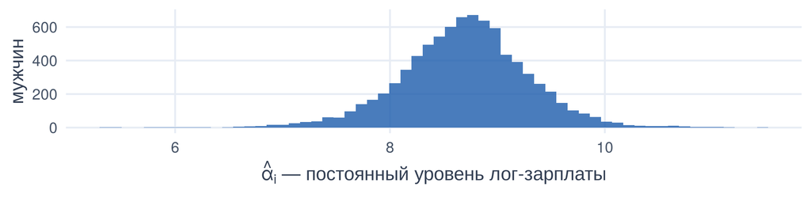

```r
fe_m  <- fixef(m_fe)                       # список: $idind, $year
alpha <- tibble(idind = as.numeric(names(fe_m$idind)), alpha = fe_m$idind) |>
  left_join(men |> group_by(idind) |> summarise(T = n(), mbar = mean(married)), by = "idind")
cor(alpha$alpha, alpha$mbar)               # связь «типа человека» с долей лет в браке
```

- Эффект 2000 года = 0 — **референтный** (`Number of references`); $\hat\alpha_i$ отсчитаны от него
- corr($\hat\alpha_i$, доля лет в браке) = 0.11. При $T_i$ = 2–3 $\hat\alpha_i$ очень шумны — не делайте из них переменную

## Как читать вывод `etable()`

- Вывод R
- Код
- С пояснениями

|  | m_pool | m_fe |
| --- | --- | --- |
|  | Pooled | FE |
| Dependent Var.: | log_wage | log_wage |
| married (женат) | 0.195*** (0.014) | 0.047** (0.015) |
| age (возраст) | 0.041*** (0.006) | 0.044*** (0.008) |
| age2 (возраст²) | -0.0006*** (7.91e-5) | -0.0006*** (7.42e-5) |
| Fixed-Effects: | ——————– | ——————– |
| year | Yes | Yes |
| idind | No | Yes |
| _______________ | ____________________ | ____________________ |
| S.E.: Clustered | by: idind | by: idind |
| Observations | 56,858 | 54,158 |
| R2 | 0.28 | 0.74 |
| Within R2 | 0.13 | 0.004 |

```r
etable(m_pool, m_fe,
       keep    = c("%married", "%^age"),       # «%» — фильтр по исходным именам, до dict
       dict    = c(married = "married (женат)", age = "age (возраст)", age2 = "age2 (возраст²)"),
       headers = c("Pooled", "FE"),            # заголовки столбцов
       fitstat = ~ n + r2 + wr2,               # N, R², within R²
       drop.section = NULL)                    # показать блок Fixed-Effects (в курсе скрыт)
```

1 · коэффициенты

Оценка, в скобках — **стандартная ошибка** (не $t$), звёзды — уровни значимости

2 · Fixed-Effects

Yes/No по каждому FE: читатель сразу видит, внутри чего идёт сравнение

3 · S.E. type

Должно совпадать во всех столбцах, иначе сравнение ошибок некорректно

4 · Observations

В FE-столбце меньше: синглтоны выброшены. Разное N = разные выборки

5 · R2 и Within R2

R² растёт от FE, within R² падает: в FE мерило — объяснённые **изменения**

6 · сигналы беды

Пропавшая строка переменной (коллинеарность), разный S.E. type, сильный скачок N

## Within-преобразование руками

```r
m_fe1 <- feols(log_wage ~ married + age + age2 | idind, data = men)   # только индивидуальные FE
men_w <- men |>
  group_by(idind) |>
  mutate(across(c(log_wage, married, age, age2), ~ .x - mean(.x), .names = "{.col}_dm")) |>
  ungroup()

c(`feols с | idind` = unname(coef(m_fe1)["married"]),
  `регрессия на отклонениях` = unname(coef(lm(log_wage_dm ~ married_dm + age_dm + age2_dm,
                                                data = men_w))["married_dm"]))
```

```
         feols с | idind регрессия на отклонениях
                  0.0424                   0.0424
```

Ровно то же число. `| idind` в `fixest` — это демининг, сделанный быстро и с правильными степенями свободы.

## Кто переключатели

```r
sw <- men |> group_by(idind) |>
  summarise(n_waves = n(), switcher = n_distinct(married) > 1,
            age_first = min(age), educ = first(educ_level))
sw |> group_by(switcher) |>
  summarise(людей = n(), `волн на человека` = mean(n_waves),
            `возраст в 1-й волне` = mean(age_first), `доля с высшим` = mean(educ == "Высшее", na.rm = TRUE))
```

| switcher | людей | волн на человека | возраст в 1-й волне | доля с высшим |
| --- | --- | --- | --- | --- |
| FALSE | 9960 | 4.83 | 34.2 | 0.260 |
| TRUE | 1118 | 7.92 | 30.3 | 0.226 |

- Эффект идентифицируют 1 118 мужчин из 11 078 — те, кто женился или развёлся на глазах у RLMS
- Они моложе и наблюдаются дольше. FE-оценка — про них, а не про «всех женатых»

## Отдача от образования: FE почти молчит

```r
ed <- rlms |> filter(age >= 22, age <= 60, employed == 1, !is.na(log_wage), !is.na(higher_ed))
m_ed_pool <- feols(log_wage ~ higher_ed + age + I(age^2) + female | year, ed, vcov = ~idind)
m_ed_fe   <- feols(log_wage ~ higher_ed + age + I(age^2) | idind + year, ed, vcov = ~idind)
etable(m_ed_pool, m_ed_fe, keep = "higher_ed", depvar = FALSE, fitstat = ~ n, headers = c("срез", "FE"))
```

|  | m_ed_pool | m_ed_fe |
| --- | --- | --- |
|  | срез | FE |
| higher_ed | 0.365*** (0.009) | 0.052*** (0.013) |
| _______________ | ________________ | ________________ |
| S.E.: Clustered | by: idind | by: idind |
| Observations | 160,586 | 153,796 |

```r
ed_sw <- ed |> group_by(idind) |> summarise(sw = n_distinct(higher_ed) > 1, age0 = min(age))
ed_sw |> summarise(переключателей = sum(sw), всего = n(), `их возраст в 1-й волне` = mean(age0[sw]))
```

| переключателей | всего | их возраст в 1-й волне |
| --- | --- | --- |
| 1849 | 28108 | 28.8 |

## Почему 0.05 — не «отдача от диплома»

0.37 → 0.05 срез → FE

1 849 переключателей

29 лет их средний возраст в 1-й волне

93% людей с неизменным дипломом

- Переключатели — только что получившие диплом. FE сравнивает их первую зарплату «с дипломом» с зарплатой студента-подработчика — это эффект **первого года после выпуска**, а не карьерная отдача
- Диплом не меняется у 93% людей — панель для этого вопроса почти бесполезна. Нужен другой источник вариации: инструменты (лекция 12)

## Курение и здоровье внутри человека

- Результат
- Код

|  | m_h_pool | m_h_fe |
| --- | --- | --- |
|  | срез | FE |
| smokes | -0.077*** (0.006) | -0.007 (0.007) |
| _______________ | _________________ | ______________ |
| S.E.: Clustered | by: idind | by: idind |
| Observations | 214,222 | 207,668 |

```r
h <- rlms |> filter(age >= 25, age <= 60, !is.na(smokes), !is.na(health_score))
m_h_pool <- feols(health_score ~ smokes + age + I(age^2) + female | year, h, vcov = ~idind)
m_h_fe   <- feols(health_score ~ smokes + age + I(age^2) | idind + year, h, vcov = ~idind)
etable(m_h_pool, m_h_fe, keep = "smokes", depvar = FALSE, fitstat = ~ n, headers = c("срез", "FE"))
```

- В срезе курильщики оценивают здоровье хуже на 0.08 балла; внутри человека — -0.007 (s.e. 0.007): эффекта нет
- Два объяснения, и FE их не различает — нужен порядок во времени (лекция 8):

а · «тип человека»

Различия курящих и некурящих постоянны

б · обратная причинность

Бросают курить **из-за** ухудшения здоровья — внутри человека

## Анатомия `plm()`

```r
pmen <- pdata.frame(men, index = c("idind", "year"))   # 1-й индекс — единица, 2-й — время
pdim(pmen)                                             # сбалансирована ли, n, T, N
```

```
Unbalanced Panel: n = 11078, T = 1-26, N = 56948
```

```r
fe_plm <- plm(log_wage ~ married + age + age2, data = pmen,
              model  = "within",     # FE; другие: "random", "pooling", "fd", "between"
              effect = "twoways")    # "individual" (по умолчанию), "time", "twoways"
```

pdata.frame

Данные «знают» панельную структуру; дубликаты пары (id, год) — ошибка, проверьте заранее

model

`within` = FE, `random` = RE (GLS), `pooling` = МНК, `fd` = первые разности

effect

`twoways` = `| idind + year` в `fixest`; `individual` = только `| idind`

ошибки

`summary()` по умолчанию даёт **iid**. Кластер — через `vcovHC()` (ниже)

## Как читать вывод `summary(plm)`

- Вывод R
- С пояснениями

```
Twoways effects Within Model
Unbalanced Panel: n = 11078, T = 1-26, N = 56948
Coefficients:
          Estimate Std. Error t-value             Pr(>|t|)
married  0.0471217  0.0106349    4.43        0.00000940844 ***
age      0.0444491  0.0069964    6.35        0.00000000021 ***
age2    -0.0006177  0.0000489  -12.63 < 0.0000000000000002 ***
Total Sum of Squares:    7610
Residual Sum of Squares: 7570
R-Squared:      0.00407
Adj. R-Squared: -0.237
F-statistic: 62.3855 on 3 and 45842 DF, p-value: <0.0000000000000002
```

1 · шапка

**Twoways effects Within Model**: FE по человеку и году. Проверьте, что это та модель, которую вы хотели

2 · Unbalanced Panel

**n** = людей, **T** = от 1 до 26 волн на человека, **N** = всего наблюдений. Balanced = все люди во всех волнах

3 · Coefficients

Те же оценки, что в `feols`. Std. Error здесь — **iid**, для статьи не годятся

4 · R-Squared

Это **within R²** (= `Within R2` в `fixest`). Adj. R² отрицателен из-за штрафа за тысячи FE — нормально

5 · F-statistic

Тест «все $X$ = 0» с iid-ошибками. Не тест на наличие FE (это `pFtest`)

6 · сигналы беды

N ≠ числу строк без пропусков; `T = 1-1`; ошибки iid в таблице статьи

## `plm` и `fixest`: одно число, разные ошибки

- Результат
- Код

| оценка | married | se |
| --- | --- | --- |
| fixest, vcov = ‘iid’ | 0.047122 | 0.010635 |
| plm, summary() (iid) | 0.047122 | 0.010635 |
| fixest, vcov = ~idind | 0.047122 | 0.014814 |
| plm, vcovHC(arellano, group) | 0.047122 | 0.014809 |
| fixest, ~idind, ssc(K.fixef = ‘none’, G.adj = FALSE) | 0.047122 | 0.014809 |

```r
v_plm <- vcovHC(fe_plm, method = "arellano", cluster = "group")   # кластер по человеку
cmp <- tibble(
  `оценка` = c("fixest, vcov = 'iid'", "plm, summary() (iid)", "fixest, vcov = ~idind",
               "plm, vcovHC(arellano, group)", "fixest, ~idind, ssc(K.fixef = 'none', G.adj = FALSE)"),
  married  = c(coef(m_fe)["married"], coef(fe_plm)["married"], coef(m_fe)["married"],
               coef(fe_plm)["married"], coef(m_fe)["married"]),
  se = c(se(m_fe, vcov = "iid")["married"], sqrt(diag(vcov(fe_plm)))["married"],
         se(m_fe)["married"], sqrt(diag(v_plm))["married"],
         se(m_fe, vcov = ~idind, ssc = ssc(K.fixef = "none", G.adj = FALSE))["married"]))
```

- Коэффициенты **совпадают** до последнего знака. Кластерные ошибки различаются в 4–5-м знаке: `fixest` (как Stata `xtreg`) умножает на поправку малой выборки ($\frac{G}{G-1}$, $\frac{N-1}{N-K}$), `plm` — нет
- Отключив поправки через `ssc(K.fixef = "none", G.adj = FALSE)`, получаем почти число `plm`. Остаток — синглтоны, которых `plm` не удаляет

## Как сообщить кластерные ошибки в `plm`

```r
coeftest(fe_plm, vcov = vcovHC(fe_plm, method = "arellano", cluster = "group"))
```

```
t test of coefficients:

          Estimate Std. Error t value             Pr(>|t|)
married  0.0471217  0.0148092    3.18               0.0015 **
age      0.0444491  0.0082594    5.38          0.000000074 ***
age2    -0.0006177  0.0000742   -8.32 < 0.0000000000000002 ***
---
Signif. codes:  0 '***' 0.001 '**' 0.01 '*' 0.05 '.' 0.1 ' ' 1
```

- `method = "arellano"` — устойчиво к гетероскедастичности **и** автокорреляции внутри человека; `cluster = "group"` — по первому индексу (`idind`), `"time"` — по году
- Таблицу для статьи из `plm` собирают через `modelsummary(fe_plm, vcov = \(x) vcovHC(x, method = "arellano"))`

## Тесты на наличие эффектов и автокорреляцию

- `pFtest`: FE против МНК
- `plmtest`: есть ли RE
- `pbgtest` / `pwartest`

```r
pFtest(fe_i, pool_i)
```

```
    F test for individual effects

data:  f_h
F = 11, df1 = 11077, df2 = 45867, p-value <0.0000000000000002
alternative hypothesis: significant effects
```

$H_0$: все $\alpha_i$ равны (хватает обычного МНК). F = 11 на (11 077, 45 867) df — индивидуальные различия огромны

```r
plmtest(pool_i, type = "bp")
```

```
    Lagrange Multiplier Test - (Breusch-Pagan)

data:  f_h
chisq = 56693, df = 1, p-value <0.0000000000000002
alternative hypothesis: significant effects
```

Лагранжев тест Бройша–Пагана: $H_0$ — дисперсия $\alpha_i$ = 0. Отвергается → МНК без учёта панели неприемлем; но это **не** выбор между FE и RE

```r
pbgtest(fe_i, order = 1)              # Бройш–Годфри/Вулдридж: автокорреляция остатков
pwartest(f_h, data = pmen)            # тест Вулдриджа для FE-моделей
```

| тест | статистика | значение | p |
| --- | --- | --- | --- |
| pbgtest | chisq | 702 | <0.0000000000000002 |
| pwartest | F | 411 | <0.0000000000000002 |

Обе нулевые гипотезы «нет автокорреляции» отвергнуты (p < 0.001) → iid-ошибки занижены, кластер по человеку **обязателен**

## Тест Хаусмана: логика

$H_0$

### $\alpha_i$ не связаны с $X$

FE и RE обе состоятельны, RE эффективнее → оценки должны быть **близки**

$H_1$

### $\alpha_i$ связаны с $X$

FE состоятельна, RE — нет → оценки **расходятся**

$$H = (\hat\beta_{FE} - \hat\beta_{RE})'\,[\hat V_{FE} - \hat V_{RE}]^{-1}\,(\hat\beta_{FE} - \hat\beta_{RE}) \sim \chi^2_k$$

```r
fe_i <- plm(log_wage ~ married + age + age2, data = pmen, model = "within")
re_i <- plm(log_wage ~ married + age + age2, data = pmen, model = "random")
phtest(fe_i, re_i)
```

- Формула $\hat V_{FE} - \hat V_{RE}$ верна, **только если RE полностью эффективна**: iid-ошибки, нормальные $\alpha_i$. В панели с автокорреляцией это ложно

## Как читать вывод `phtest()`

- Вывод R
- С пояснениями

```
    Hausman Test

data:  f_h
chisq = 3997, df = 3, p-value <0.0000000000000002
alternative hypothesis: one model is inconsistent
```

1 · data

Формула, по которой сравнивали. Оба объекта должны иметь одинаковые $X$ и выборку

2 · chisq

Статистика $H$ = 3 997. Чем больше, тем сильнее расходятся FE и RE относительно шума

3 · df

Число **сравниваемых** коэффициентов (только меняющиеся во времени): здесь 3

4 · p-value

$p$ < 0.05 → RE отвергнута. Не «FE верна»: FE — поддерживаемая гипотеза, тест её не проверяет

5 · alternative

«one model is inconsistent» — какая именно, тест не говорит; по построению это RE

6 · сигналы беды

Отрицательная $\chi^2$ (матрица $V_{FE} - V_{RE}$ не положительна); классический тест при кластерных ошибках; N в сотни тысяч → отвергает всегда

## Что именно отвергнуто

```r
b_fe <- coef(fe_i); b_re <- coef(re_i)[names(b_fe)]
V_d  <- vcov(fe_i) - vcov(re_i)[names(b_fe), names(b_fe)]
tibble(term = names(b_fe), FE = b_fe, RE = b_re, `разница` = b_fe - b_re,
       z = (b_fe - b_re) / sqrt(diag(V_d))) |> mutate(across(-term, \(x) formatC(x, digits = 3, format = "g")))
```

| term | FE | RE | разница | z |
| --- | --- | --- | --- | --- |
| married | 0.0424 | 0.0444 | -0.00197 | -0.341 |
| age | 0.0647 | 0.0606 | 0.00404 | 4.43 |
| age2 | -0.00039 | -0.000521 | 0.000132 | 11.3 |

- Тест **совместный**. Покоэффициентно: `married` в FE и RE почти одинаков ($z$ = -0.34), а отвержение даёт **возрастной профиль**
- RE-оценка брака близка к FE не потому, что RE верна: $\hat\theta$ в среднем 0.72 — RE почти целиком внутри-человеческая

## Робастный тест Хаусмана в `plm`

```r
h_rob <- phtest(log_wage ~ married + age + age2, data = pmen, method = "aux",
                vcov = function(x) vcovHC(x, method = "arellano"))
h_rob
```

```
    Regression-based Hausman test, vcov: function(x) vcovHC(x, method = "arellano")

data:  log_wage ~ married + age + age2
chisq = 7107, df = 3, p-value <0.0000000000000002
alternative hypothesis: one model is inconsistent
```

- `method = "aux"` — регрессионная версия (Wooldridge 2010, §10.7.3): RE-регрессия + within-отклонения $X$; проверяем, что их коэффициенты = 0
- Только её можно сделать робастной: `vcov =` принимает **функцию** от модели. Здесь вывод тот же ($\chi^2$ = 7 107 против 3 997), но так бывает не всегда

## Мундлак: тест Хаусмана руками

```r
men_m <- men |> group_by(idind) |>
  mutate(married_bar = mean(married), age_bar = mean(age), age2_bar = mean(age2)) |> ungroup()
m_mund <- feols(log_wage ~ married + age + age2 + married_bar + age_bar + age2_bar,
                data = men_m, vcov = ~idind)
w_mund <- wald(m_mund, keep = "_bar", print = FALSE)
coeftable(m_mund)[c("married", "married_bar"), 1:3] |> round(3)
```

```
            Estimate Std. Error t value
married        0.042      0.016    2.61
married_bar    0.164      0.025    6.56
```

married

0.0424 — **ровно** FE с `| idind` (0.0424)

married_bar

0.16: те, кто чаще женат, имеют выше **постоянную** зарплату — это селекция

wald(…, keep = “_bar”)

$F$(3, 11 077) = 438, кластер по idind → RE отвергнута

## Как писать результат: FE или RE

шаблон

«Робастный тест Хаусмана в форме Мундлака (Wooldridge 2010, §10.7.3; ошибки кластеризованы по индивиду) отвергает допущение модели случайных эффектов: средние по индивиду совместно значимы, *F*(3, 11 077) = 438, *p* < 0.001. Мужчины, которые чаще состоят в браке, имеют более высокий постоянный уровень заработков (коэффициент при средней = 0.16). Поэтому основная спецификация — модель с фиксированными эффектами индивида и года: вступление в брак связано с ростом заработной платы на **4.7%** (s.e. = 1.5 п. п.).»

- Называйте **версию** теста и тип ошибок. «Тест Хаусмана показал, что нужна FE» без деталей — недостаточно
- Не пишите «FE-модель верна»: тест отвергает RE, а не подтверждает отсутствие меняющихся во времени конфаундеров

## Дети до 3 лет и занятость: данные

```r
wm <- rlms |>
  filter(female == 1, age >= 20, age <= 45, !is.na(work_status),
         !in_university %in% 1, !in_school %in% 1) |>
  mutate(yk = year - pmax(child1_birth_year, child2_birth_year, child3_birth_year, na.rm = TRUE),
         kid_u3  = as.integer(!is.na(yk) & yk >= 0 & yk < 3),   # младшему ребёнку < 3 лет
         married = coalesce(married, 0L))
```

77% наблюдений: есть работа (включая декрет)

12% наблюдений: ребёнок до 3 лет

38% женщин (≥ 2 волн): занятость менялась

34% женщин (≥ 2 волн): `kid_u3` менялся

- `employed` = 1 при `j1` = 1–4: работает **или в отпуске**, в т. ч. декретном. Вопрос — о потере работы, а не о выходе в декрет

## Линейная модель вероятности с FE

```r
lpm <- feols(employed ~ kid_u3 + married | idind + year, data = wm, vcov = ~idind)
summary(lpm)
```

```
OLS estimation, Dep. Var.: employed
Observations: 78,012
Fixed-effects: idind: 10,406,  year: 26
Standard-errors: Clustered (idind)
        Estimate Std. Error t value            Pr(>|t|)
kid_u3   -0.0416    0.00573   -7.26 0.00000000000042535 ***
married  -0.0170    0.00674   -2.52 0.01174253661745530 *
---
Signif. codes:  0 '***' 0.001 '**' 0.01 '*' 0.05 '.' 0.1 ' ' 1
RMSE: 0.277451     Adj. R2: 0.500037
                 Within R2: 0.002049
```

- Коэффициент `kid_u3` = -0.042: когда у женщины появляется ребёнок до 3 лет, вероятность иметь работу ниже на **4.2 п. п.**
- Плюсы: те же FE и ошибки, что для зарплаты; интерпретация прямо в п. п. Минус: линейность, прогнозы вне [0, 1]

## FE-логит в `fixest`: `feglm()`

```r
lgt <- feglm(employed ~ kid_u3 + married | idind + year, data = wm,
             family = binomial("logit"), vcov = ~idind)
```

81 254 наблюдений на входе

37 745 осталось в модели

9 666 женщин выброшено: $y$ не менялся (или 1 волна)

- Если женщина всегда работала, $\hat\alpha_i \to +\infty$ объясняет всё, и она ничего не говорит о $\beta$. `fixest` удаляет такие FE сам (`fixef.rm = "perfect_fit"`); список — в `lgt$fixef_removed`
- Это **не потеря данных**, а честная граница: оценка — про 37 745 наблюдений женщин, чья занятость менялась

## Как читать вывод `summary(feglm)`

- Вывод R
- С пояснениями

```
GLM estimation, family = binomial, Dep. Var.: employed
Observations: 37,745
Fixed-effects: idind: 3,982,  year: 26
Standard-errors: Clustered (idind)
        Estimate Std. Error z value            Pr(>|z|)
kid_u3    -0.437     0.0596   -7.33 0.00000000000022732 ***
married   -0.202     0.0761   -2.66 0.00784567603356063 **
---
Signif. codes:  0 '***' 0.001 '**' 0.01 '*' 0.05 '.' 0.1 ' ' 1
Log-Likelihood: -18,088.1   Adj. Pseudo R2: 0.086573
           BIC:  78,425.6     Squared Cor.: 0.302881
```

1 · шапка

**GLM, binomial**; Observations — **после** удаления женщин без вариации $y$. Fixed-effects — сколько женщин осталось

2 · Estimate

Лог-шансы: `kid_u3` = -0.437. Не п. п.! Отношение шансов: $e^{\hat\beta}$ = 0.65

3 · z value

Асимптотическая нормальность; ошибки кластеризованы по idind (мы указали `vcov`)

4 · Log-Likelihood, BIC

Для сравнения вложенных моделей на **одной** выборке

5 · Pseudo R2, Squared Cor.

Описательные меры подгонки, к идентификации отношения не имеют

6 · сигналы беды

Безусловный ML: при малом $T$ коэффициент **смещён от нуля**. Нужна поправка или `clogit` (дальше)

## Инцидентные параметры: `bife` и поправка

```r
bf    <- bife(employed ~ kid_u3 + married + factor(year) | idind, data = wm, model = "logit")
bf_bc <- bias_corr(bf)            # аналитическая поправка Fernández-Val, Weidner (2016)
```

| модель | kid_u3 | married |
| --- | --- | --- |
| feglm (fixest) | -0.437 | -0.202 |
| bife, без поправки | -0.437 | -0.202 |
| bife + bias_corr() | -0.389 | -0.182 |

- `feglm` и `bife` — **одна и та же** оценка (безусловный ML с дамми на человека); `bife` знает только один FE, годы — дамми `factor(year)`
- Поправка сдвигает коэффициент к нулю на 11%: при среднем $T$ ≈ 9.5 волн смещение заметное

## Как читать вывод `bife`

- Вывод R
- С пояснениями

```
binomial - logit link
employed ~ kid_u3 + married + factor(year) | idind
Estimates:
                 Estimate Std. error z value            Pr(> |z|)
kid_u3            -0.3895     0.0427   -9.12 < 0.0000000000000002 ***
married           -0.1818     0.0516   -3.52              0.00043 ***
---
residual deviance= 36176,
null deviance= 48381,
n= 37745, N= 3982

( 43509 observation(s) deleted due to perfect classification )
Average individual fixed effect= -0.393
```

1 · шапка

`binomial - logit link` и формула: FE — после `|`, только **один**

2 · Estimates

Лог-шансы **после** поправки (если печатаем `bias_corr`-объект). Ошибки не кластеризованы

3 · n и N

**n** = наблюдений в оценке, **N** = женщин. Совпадают с `feglm`

4 · perfect classification

Сколько наблюдений выброшено: женщины с постоянным $y$ (и с одной волной)

5 · Average individual FE

Средний $\hat\alpha_i$; сам по себе не интерпретируется

6 · сигналы беды

Поправка меняет оценку на десятки процентов → $T$ мал, доверяйте `clogit`; много итераций / нет сходимости

## Условный логит: `clogit()`

```r
cl <- clogit(employed ~ kid_u3 + married + factor(year) + strata(idind), data = wm, method = "exact")
```

| модель | kid_u3 | se | отношение шансов |
| --- | --- | --- | --- |
| feglm / bife (безусловный ML) | -0.437 | 0.060 | 0.646 |
| bife + bias_corr() | -0.389 | 0.043 | 0.677 |
| clogit (условный ML) | -0.387 | 0.040 | 0.679 |

- `strata(idind)` — условие на число единиц у каждой женщины: $\alpha_i$ исключается **точно**, без оценки. Женщины без вариации $y$ не вносят вклада сами
- Поправленный `bife` почти совпал с `clogit`; безусловный ML завышает эффект по модулю. Ошибки `clogit` — модельные (не кластерные)

## Отношения шансов

```r
or_cl <- exp(coef(cl)["kid_u3"]); ci_cl <- exp(confint(cl)["kid_u3", ])
round(c(OR = unname(or_cl), `2.5%` = unname(ci_cl[1]), `97.5%` = unname(ci_cl[2])), 3)
```

```
   OR  2.5% 97.5%
0.679 0.628 0.735
```

- $e^{\hat\beta}$ = 0.68 (`clogit`): при ребёнке до 3 лет **шансы** иметь работу, p / (1 − p), умножаются на 0.68, т. е. ниже на 32%
- Шансы ≠ вероятность: при $p$ = 0.9 падение шансов на 32% — это одно число п. п., при $p$ = 0.5 — другое. Для п. п. нужны предельные эффекты
- Доверительный интервал считаем на шкале коэффициента и **потом** экспонируем (как `confint()` выше)

## От коэффициентов к вероятностям

```r
me_lgt <- avg_slopes(lgt, variables = "kid_u3")      # marginaleffects: среднее по выборке модели
ape_bc <- get_APEs(bf_bc)                             # bife: APE с поправкой смещения
lpm_mv <- feols(employed ~ kid_u3 + married | idind + year, data = wm[obs(lgt), ], vcov = ~idind)
```

| оценка | эффект, п. п. | над кем усредняем |
| --- | --- | --- |
| LPM, все женщины | -4.2 | 78 012 |
| LPM, только с вариацией y | -7.1 | 37 745 |
| FE-логит: avg_slopes() | -7.1 | 37 745 |
| bife: get_APEs() | -3.3 | 81 254 (у неподвижных 0) |
| bife + bias_corr: get_APEs() | -3.7 | 81 254 (у неподвижных 0) |

- `avg_slopes(m, variables = "x")`: для бинарного `x` — $\hat p(x{=}1) - \hat p(x{=}0)$ для каждого наблюдения **выборки модели**, затем среднее; s.e. дельта-методом по `vcov` модели (у нас кластер). В FE-логите $\hat p$ включает $\hat\alpha_i$
- `get_APEs()` — то же в `bife` (после `bias_corr()` — с поправкой), но делит на **все** 81 254 наблюдений, включая синглтоны и «неподвижных»; ошибки не кластерные

## Над кем усредняем — главный вопрос

avg_slopes(feglm)

### Только «подвижные»

Среднее по 37 745 наблюдениям женщин с меняющейся занятостью. Использует $\hat\alpha_i$ — а они смещены при малом $T$

get_APEs(bife)

### Все, у неподвижных — 0

Для женщин с постоянным $y$ модель полагает $\alpha_i = \pm\infty$ и эффект 0. Это **допущение модели**, а не данные

LPM

### Взвешенное среднее

Коэффициент — среднее с весами по within-дисперсии `kid_u3`, без предположения о форме связи

На одной выборке LPM и FE-логит дают почти одно и то же (-7.1 и -7.1 п. п.). Различия в таблице — в основном **разные популяции**, а не разные модели. Всегда пишите, по кому усреднён эффект.

## Как писать результат: бинарный исход

шаблон

«В модели с фиксированными эффектами индивида и года наличие ребёнка младше 3 лет связано со снижением вероятности иметь работу на **4.2 п. п.** (линейная модель вероятности, s.e. = 0.6, ошибки кластеризованы по индивиду). Условный логит даёт отношение шансов 0.68 (95% ДИ 0.63–0.73); эффект идентифицирован по 37 745 наблюдениям 3 982 женщин, чья занятость менялась за период наблюдения. Для них средний предельный эффект — снижение на 7.1 п. п.»

- Обязательно: какая модель главная, **по кому** усреднён эффект, сколько единиц выброшено и почему
- Не пишите «шансы ниже на 32%» как «вероятность ниже на 32%»

## Диагностика 1: есть ли вариация внутри человека

- Результат
- Код функции

| переменная | доля людей (≥ 2 волн) с изменением | within SD / общее SD |
| --- | --- | --- |
| married | 0.13 | 0.43 |
| higher_ed | 0.07 | 0.27 |
| urban | 0.00 | 0.04 |
| official | 0.18 | 0.66 |
| state_owned | 0.36 | 0.56 |

```r
within_check <- function(d, vars, id = "idind") {
  map_dfr(vars, \(v) {
    x  <- d[[v]]; g <- d[[id]]; ok <- !is.na(x)
    xd <- x[ok] - ave(x[ok], g[ok])                        # отклонение от среднего по человеку
    n_i <- tapply(x[ok], g[ok], length); ch <- tapply(x[ok], g[ok], \(z) length(unique(z)) > 1)
    tibble(переменная = v,
           `доля людей (≥ 2 волн) с изменением` = mean(ch[n_i > 1]),
           `within SD / общее SD` = sd(xd) / sd(x[ok]))
  })
}
within_check(men, c("married", "higher_ed", "urban", "official", "state_owned")) |>
  mutate(across(where(is.numeric), \(x) round(x, 2)))
```

- Доля людей с изменением — кто вообще даёт информацию для FE; within SD / общее SD — какая часть разброса остаётся после вычитания средних по человеку
- Мало вариации → FE держится на горстке людей и на **ошибках кодирования**; `urban` почти не меняется — в FE неинформативен

## Диагностика 2: коллинеарность с FE

```r
m_col <- feols(log_wage ~ married + I(year - birth_year) + birth_year | idind + year,
               data = men, vcov = ~idind)
m_col$collin.var          # что выброшено молча
```

```
[1] "I(year - birth_year)" "birth_year"
```

- `birth_year` постоянен → поглощён `idind`. `year − birth_year` = год − константа → поглощён `idind + year`. `fixest` удаляет их и пишет об этом в `summary()`
- А `age` в нашей модели выжил: он записан на дату интервью и отличается от `year − birth_year` у 15% наблюдений. Коэффициент при `age` держится только на этом — **не интерпретируйте** его

Если коллинеарна **интересующая** переменная, модель неверно поставлена. Автоматическое удаление — для контролей (Bergé, «On collinearity»).

## Диагностика 3: синглтоны и `fixef.rm`

```r
m_none <- feols(log_wage ~ married + age + age2 | idind + year, men, vcov = ~idind, fixef.rm = "none")
tibble(fixef.rm = c('"perfect_fit" (по умолч.)', '"none"'), N = c(nobs(m_fe), nobs(m_none)),
       married = c(coef(m_fe)["married"], coef(m_none)["married"]),
       se = c(se(m_fe)["married"], se(m_none)["married"])) |> mutate(across(c(married, se), \(x) round(x, 5)))
```

| fixef.rm | N | married | se |
| --- | --- | --- | --- |
| “perfect_fit” (по умолч.) | 54158 | 0.047 | 0.015 |
| “none” | 56948 | 0.047 | 0.015 |

- Синглтон — человек с одной волной: его $\alpha_i$ объясняет наблюдение полностью. Удаление **не меняет** коэффициенты, только N и (слегка) ошибки
- Сообщайте N **после** удаления и сколько выброшено: `nobs(m)`, `m$nobs_origin`, `m$fixef_removed`

```r
set.seed(7)
sim <- expand_grid(id = 1:3000, t = 1:5) |>
  group_by(id) |> mutate(alpha = rnorm(1), d_true = rbinom(5, 1, 0.5)) |> ungroup() |>
  mutate(y = 1 + 0.5 * d_true + alpha + rnorm(n()),
         d_obs = ifelse(runif(n()) < 0.15, 1 - d_true, d_true))       # 15 % ответов ошибочны
c(`OLS, D без ошибок` = coef(feols(y ~ d_true, sim))["d_true"],
  `OLS, D с ошибками` = coef(feols(y ~ d_obs, sim))["d_obs"],
  `FE, D с ошибками`  = coef(feols(y ~ d_obs | id, sim))["d_obs"])
```

```
OLS, D без ошибок.d_true  OLS, D с ошибками.d_obs   FE, D с ошибками.d_obs
                   0.481                    0.329                    0.351
```

# Как ошибаются

## Восемь ошибок с FE

ошибка 1

### «Добавили FE — убрали эндогенность»

**Как правильно:** FE убирает только постоянное во времени. Меняющиеся конфаундеры и обратная причинность остаются

ошибка 2

### Не смотрят на переключателей

**Как правильно:** посчитать, сколько людей меняли $D$, описать их; оценка — про них

ошибка 3

### iid-ошибки по умолчанию

**Как правильно:** в `fixest` и `plm` по умолчанию iid. Всегда `vcov = ~idind` / `vcovHC(..., "arellano")`

ошибка 4

### Хаусман как ритуал

**Как правильно:** классический тест при кластерных ошибках некорректен. Робастный `phtest(method = "aux")` или Мундлак + содержательный аргумент

## Восемь ошибок с FE (2)

ошибка 5

### Контроли-последствия и лаг исхода

**Как правильно:** не включать должность «после брака»; лаг $y$ при малом $T$ — смещение Никелла

ошибка 6

### Коэффициент логита как п. п.

**Как правильно:** лог-шансы → отношение шансов $e^\beta$ или средний предельный эффект

ошибка 7

### Безусловный FE-логит при малом $T$

**Как правильно:** `clogit` или `bife::bias_corr()`; сравнить оба

ошибка 8

### APE без популяции

**Как правильно:** указать, по кому усреднено: все, «подвижные», с нулём для «неподвижных»

## Чек-лист

- Названо, какие ненаблюдаемые считаем постоянными — и почему это правдоподобно
- Подсчитаны переключатели и within-вариация; описано, чем переключатели отличаются
- Контроли меняются во времени и не являются следствиями воздействия; `collin.var` пуст для ключевых $X$
- Двусторонние FE + кластер по человеку; N после удаления синглтонов указан
- FE против RE — робастный тест (Мундлак / `method = "aux"`), а не классический `phtest`
- Бинарный исход: LPM + `clogit`/`bias_corr`; эффект в п. п. с указанием популяции
- Проверено, не предшествует ли изменение исхода изменению воздействия (лекция 8); обсуждена ошибка измерения

# Мини-задача

## Задание к следующему занятию

1. Оцените «премию за брак» для женщин 25–50 лет в срезе и с FE в `fixest` **и** `plm`; убедитесь, что коэффициенты совпадают. Кто переключатели?
2. Для той же модели проведите классический и робастный тест Хаусмана и тест Мундлака. Напишите абзац результата по шаблону
3. Эффект **официального оформления** (`official`) на зарплату: срез → FE → FE с кластером по площадке → FE с `site_code^year`. Как меняется оценка и ошибка?
4. Бинарный исход: `smokes ~ married` у мужчин 25–50. LPM, `feglm`, `bife` + `bias_corr`, `clogit`; средние предельные эффекты. Сколько мужчин выброшено и почему?
5. Повторите симуляцию с ошибкой измерения: 30 % ошибок и 10 волн. Что происходит с FE-оценкой?

# Литература

## Что прочитать

- Wooldridge J. (2010). *Econometric Analysis of Cross Section and Panel Data*, 2nd ed. Гл. 10 (FE, RE, тест Хаусмана, §10.7.3 — робастная версия), гл. 15 (бинарные исходы, условный логит, CRE-пробит)
- Angrist J., Pischke J.-S. *Mostly Harmless Econometrics*, гл. 5; Huntington-Klein N. *The Effect*, гл. 16
- Croissant Y., Millo G. (2008). Panel Data Econometrics in R: The plm Package. *JSS* 27(2); Croissant Y., Millo G. (2018). *Panel Data Econometrics with R*. Wiley
- Bergé L. (2018). Efficient estimation of maximum likelihood models with multiple fixed-effects: the R package FENmlm. *CREA DP*; виньетки `fixest`: walkthrough, standard errors, multiple estimations, collinearity
- Mundlak Y. (1978). On the Pooling of Time Series and Cross Section Data. *Econometrica*; Hausman J. (1978). Specification Tests in Econometrics. *Econometrica*
- Chamberlain G. (1980). Analysis of Covariance with Qualitative Data. *REStud* — условный логит
- Fernández-Val I., Weidner M. (2016). Individual and time effects in nonlinear panel models with large N, T. *J. of Econometrics*; Stammann A. (2018). Fast and Feasible Estimation of Generalized Linear Models with High-Dimensional k-way Fixed Effects. arXiv — пакеты `bife`, `alpaca`
- Imai K., Kim I. S. (2019). When Should We Use Unit Fixed Effects Regression Models for Causal Inference with Longitudinal Data? *AJPS*

Каузальный анализ в R · RLMS-HSE · К. Аванесян

← К программе курса